# Práctica 2: Limpieza y validación de los datos

Alejandro Manuel Olivares Luque y Gabriel Villalba Pintado

11 de junio, 2018

# Práctica 2: Limpieza y validación de los datos

Enlace a GitHub: https://github.com/gabvilpi/ATPstatistics-cleaning

## 1. Descripción del dataset

La Asociación de Tenistas Profesionales (ATP) organiza diferentes torneos en una misma temporada, que abarca de Enero a Noviembre. Los torneos se clasifican según la puntuación que el ganador recibe en cada uno de ellos:

- ATP 250
- ATP 500
- ATP 1000
- Grand Slam (2000)

Por lo tanto, los ganadores se embolsan desde 250 puntos en el primero torneo hasta los 2000 de un Grand Slam. Esta puntuación se utiliza para realizar la clasificación de los tenistas en el ranking mundial. Los tenistas con mejor ranking disponen de plazas directas para jugar los torneos, mientras que el resto tendrá que jugar un mini torneo para poder acceder a ellos.

Además de la puntuación, los torneos difieren en la cantidad de tenistas que participan en ellos, diferencia que va desde los 28 tenistas que disputan un ATP 250 hasta los 128 de un Grand Slam.

El dataset “ATPStatistics” utilizado para esta práctica, es un set de datos sobre la competición ATP World Tour que se ha obtenido mediante un proyecto de web Scraping de la página http://www.atpworldtour.com/ desarrollado por Alejandro Manuel Olivares Luque.

En dicho proyecto se ha realizado la extracción de datos, estadísticas y resultados de los partidos oficiales organizados por Asociación de Tenistas Profesionales (ATP).

El desarrollo del scrapper se ha realizado mediante el lenguaje Python y haciendo uso de librerías adicionales como urllib2, beautifulsoup y xlwt. Todo el código se encuentra disponible en Github en el siguiente enlace: https://github.com/olivaresluque/scrapATP

- id_partido: Código identificador únido del partido
- Player 1: Nombre del jugador 1 del partido
- Player 2: Nombre del jugador 2 del partido
- Serve Rating 1: Puntuación oficial del saque para el jugador 1
- Serve Rating 2: Puntuación oficial del saque para el jugador 2
- Aces 1: Cantidad de ACEs del jugador 1 en el partido
- Aces 2: Cantidad de ACEs del jugador 2 en el partido
- Double Faults 1: Número de faltas dobles del jugador 1 en el partido
- Double Faults 2: Número de faltas dobles del jugador 2 en el partido
- % 1st Serve 1: Porcentaje de servicios correctos en el primer servicio para el jugador 1
- % 1st Serve 2: Porcentaje de servicios correctos en el primer servicio para el jugador 2
- % 1st Serve Won 1: Porcentaje de puntos ganados con el primer servicio para el jugador 1
- % 1st Serve Won 2: Porcentaje de puntos ganados con el primer servicio para el jugador 2
- % 2nd Serve Won 1: Porcentaje de puntos ganados con el segundo servicio para el jugador 1
- % 2nd Serve Won 2: : Porcentaje de puntos ganados con el segundo servicio para el jugador 2
- % Break Point Saved 1: Porcentaje de puntos de break salvados por el jugador 1
- % Break Point Saved 2: Porcentaje de puntos de break salvados por el jugador 2
- Served Games Played 1: Número de juegos en los que ha tenido servicio el jugador 1
- Served Games Played 2: Número de juegos en los que ha tenido servicio el jugador 2
- Return Rating 1: Puntuación oficial de resto para el jugador 1
- Return Rating 2: Puntuación oficial de resto para el jugador 2
- % 1st Serve Return Won 1: Porcentaje de puntos ganados restando el primer servicio por el jugador 1
- % 1st Serve Return Won 2: Porcentaje de puntos ganados restando el primer servicio por el jugador 2
- % 2nd Serve Return Won 1: Porcentaje de puntos ganados restando el segundo servicio por el jugador 1
- % 2nd Serve Return Won 2: Porcentaje de puntos ganados restando el segundo servicio por el jugador 2
- % Break Point Converted 1: Porcentaje de puntos de break convertidos por el jugador 1
- % Break Point Converted 2: Porcentaje de puntos de break convertidos por el jugador 2
- Return Games Played 1: Número de juegos en los que ha restado el jugador 1
- Return Games Played 2: Número de juegos en los que ha restado el jugador 2
- % Served Point Won 1: Porcentaje de puntos ganados con su servicio para el jugador 1
- % Served Point Won 2: Porcentaje de puntos ganados con su servicio para el jugador 2
- % Return Point Won 1: Porcentaje de puntos ganados con su resto para el jugador 1
- % Return Point Won 2: Porcentaje de puntos ganados con su resto para el jugador 2
- % Total Point Won 1: Porcentaje total de puntos ganados por el jugador 1
- % Total Point Won 2: Porcentaje total de puntos ganados por el jugador 2
- Winner: Nombre del ganador del partido
- Tournament: Nombre del torneo
- Started date: Fecha de inicio del torneo
- Ended date: Fecha de fin del torneo
- Surface: Superficie del torneo

La extracción de estos datos tiene como objetivo crear un almacén de datos con el que realizar un estudio estadístico y construir un modelo de clasificación que permita predecir el ganador de nuevos partidos o torneos.

## 2. Integración y selección de los datos de interés a analizar

En primer lugar realizamos la carga del dataset ATPStatistics y mostramos sus primeras lineas para revisar que se ha realizado correctamente.

```r
library(readxl)
ATPstatistics <- read_excel("../Data/ATPstatistics.xlsx")
head(ATPstatistics)
```

```
## # A tibble: 6 x 40
##   id_pa~ `Pla~ `Pla~ `Ser~ `Ser~ `Ace~ `Ace~ `Dou~ `Dou~ `% 1~ `% 1~ `% 1~
##    <dbl> <chr> <chr> <chr> <chr> <chr> <chr> <chr> <chr> <chr> <chr> <chr>
## 1   1.00 Mart~ Pete~ 313   199   6     1     1     2     56    50    91
## 2   2.00 Pete~ Fabi~ 276   232   7     5     1     2     63    70    82
## 3   3.00 Mart~ Stev~ 250   218   5     0     3     4     56    58    67
## 4   4.00 Fabi~ Tenn~ 279   285   4     9     1     3     63    62    72
## 5   5.00 Mart~ Stan~ 273   200   1     1     2     0     53    70    69
## 6   6.00 Stev~ Guid~ 307   269   6     9     0     2     70    55    81
## # ... with 28 more variables: `% 1st Serve Won 2` <chr>, `% 2nd Serve Won
## #   1` <chr>, `% 2nd Serve Won 2` <chr>, `% Break Point Saved 1` <chr>, `%
## #   Break Point Saved 2` <chr>, `Served Games Played 1` <chr>, `Served
## #   Games Played 2` <chr>, `Return Rating 1` <chr>, `Return Rating 2`
## #   <chr>, `% 1st Serve Return Won 1` <chr>, `% 1st Serve Return Won 2`
## #   <chr>, `% 2nd Serve Return Won 1` <chr>, `% 2nd Serve Return Won 2`
## #   <chr>, `% Break Point Converted 1` <chr>, `% Break Point Converted 2`
## #   <chr>, `Return Games Played 1` <chr>, `Return Games Played 2` <chr>,
## #   `% Served Point Won 1` <chr>, `% Served Point Won 2` <chr>, `% Return
## #   Point Won 1` <chr>, `% Return Point Won 2` <chr>, `% Total Point Won
## #   1` <chr>, `% Total Point Won 2` <chr>, Winner <chr>, Tournament <chr>,
## #   `Started date` <chr>, `Ended date` <chr>, Surface <chr>
```

Una vez cargado el set de datos procedemos a realizar un estudio de la estructura de los diferentes atributos para ver que tipo le ha asignado R a cada uno de ellos.

```r
str(ATPstatistics)
```

```
## Classes 'tbl_df', 'tbl' and 'data.frame':    34827 obs. of  40 variables:
##  $ id_partido               : num  1 2 3 4 5 6 7 8 9 10 ...
##  $ Player 1                 : chr  "Marton Fucsovics" "Peter Gojowczyk" "Marton Fucsovics" "Fabio Fognini" ...
##  $ Player 2                 : chr  "Peter Gojowczyk" "Fabio Fognini" "Steve Johnson" "Tennys Sandgren" ...
##  $ Serve Rating 1           : chr  "313" "276" "250" "279" ...
##  $ Serve Rating 2           : chr  "199" "232" "218" "285" ...
##  $ Aces 1                   : chr  "6" "7" "5" "4" ...
##  $ Aces 2                   : chr  "1" "5" "0" "9" ...
##  $ Double Faults 1          : chr  "1" "1" "3" "1" ...
##  $ Double Faults 2          : chr  "2" "2" "4" "3" ...
##  $ % 1st Serve 1            : chr  "56" "63" "56" "63" ...
##  $ % 1st Serve 2            : chr  "50" "70" "58" "62" ...
##  $ % 1st Serve Won 1        : chr  "91" "82" "67" "72" ...
##  $ % 1st Serve Won 2        : chr  "52" "57" "63" "79" ...
##  $ % 2nd Serve Won 1        : chr  "61" "45" "50" "58" ...
```

[output cut: 26 more lines]

Como podemos observar, R no ha asignado el tipo de dato correcto o más adeacudo a los atributos. Por lo tanto, a continuación realizaremos una conversión del tipo de dato para cada uno de los atributos. También aprovechamos para transformar los datos que indican un porcentaje. Por último volvemos a mostrar la estructura del set de datos para observar los cambios realizados en los atributos.

```r
ATPstatistics$id_partido<-as.integer(ATPstatistics$id_partido)
ATPstatistics$`Player 1`<-as.factor(ATPstatistics$`Player 1`)
ATPstatistics$`Player 2`<-as.factor(ATPstatistics$`Player 2`)
ATPstatistics$`Serve Rating 1` <- as.integer(ATPstatistics$`Serve Rating 1`)
ATPstatistics$`Serve Rating 2` <- as.integer(ATPstatistics$`Serve Rating 2`)
ATPstatistics$`Aces 1`<- as.integer(ATPstatistics$`Aces 1`)
ATPstatistics$`Aces 2`<- as.integer(ATPstatistics$`Aces 2`)
ATPstatistics$`Double Faults 1` <- as.integer(ATPstatistics$`Double Faults 1`)
ATPstatistics$`Double Faults 2` <- as.integer(ATPstatistics$`Double Faults 2`)
ATPstatistics$`Served Games Played 1` <- as.integer(ATPstatistics$`Served Games Played 1`)
ATPstatistics$`Served Games Played 2` <- as.integer(ATPstatistics$`Served Games Played 2`)
ATPstatistics$`Return Rating 1` <- as.integer(ATPstatistics$`Return Rating 1`)
ATPstatistics$`Return Rating 2` <- as.integer(ATPstatistics$`Return Rating 2`)
ATPstatistics$`Return Games Played 1` <- as.integer(ATPstatistics$`Return Games Played 1`)
ATPstatistics$`Return Games Played 2` <- as.integer(ATPstatistics$`Return Games Played 2`)
ATPstatistics$Winner <- as.factor(ATPstatistics$Winner)
ATPstatistics$Tournament <- as.factor(ATPstatistics$Tournament)
ATPstatistics$`Started date` <- as.Date(as.character(ATPstatistics$`Started date`), "%d/%m/%Y")
ATPstatistics$`Ended date` <- as.Date(as.character(ATPstatistics$`Ended date`),  "%d/%m/%Y")
ATPstatistics$Surface <- as.factor(ATPstatistics$Surface)
ATPstatistics$`% 1st Serve 1` <- as.double(ATPstatistics$`% 1st Serve 1`)/100
ATPstatistics$`% 1st Serve 2` <- as.double(ATPstatistics$`% 1st Serve 2`)/100
ATPstatistics$`% 1st Serve Won 1` <-as.double(ATPstatistics$`% 1st Serve Won 1`)/100
ATPstatistics$`% 1st Serve Won 2` <-as.double(ATPstatistics$`% 1st Serve Won 2`)/100
ATPstatistics$`% 2nd Serve Won 1` <-as.double(ATPstatistics$`% 2nd Serve Won 1`)/100
ATPstatistics$`% 2nd Serve Won 2` <-as.double(ATPstatistics$`% 2nd Serve Won 2`)/100
ATPstatistics$`% Break Point Saved 1` <- as.double(ATPstatistics$`% Break Point Saved 1`)/100
ATPstatistics$`% Break Point Saved 2` <- as.double(ATPstatistics$`% Break Point Saved 2`)/100
ATPstatistics$`% Served Point Won 1` <- as.double(ATPstatistics$`% Served Point Won 1`)/100
ATPstatistics$`% Served Point Won 2` <- as.double(ATPstatistics$`% Served Point Won 2`)/100
ATPstatistics$`% Return Point Won 1` <- as.double(ATPstatistics$`% Return Point Won 1`)/100
ATPstatistics$`% Return Point Won 2` <- as.double(ATPstatistics$`% Return Point Won 2`)/100
ATPstatistics$`% Total Point Won 1` <- as.double(ATPstatistics$`% Total Point Won 1`)/100
ATPstatistics$`% Total Point Won 2` <- as.double(ATPstatistics$`% Total Point Won 2`)/100
ATPstatistics$`% 1st Serve Return Won 1` <- as.double(ATPstatistics$`% 1st Serve Return Won 1`)/100
ATPstatistics$`% 1st Serve Return Won 2` <- as.double(ATPstatistics$`% 1st Serve Return Won 2` )/100
ATPstatistics$`% 2nd Serve Return Won 1`<- as.double(ATPstatistics$`% 2nd Serve Return Won 1`)/100
ATPstatistics$`% 2nd Serve Return Won 2`<- as.double(ATPstatistics$`% 2nd Serve Return Won 2`)/100
ATPstatistics$`% Break Point Converted 1`<- as.double(ATPstatistics$`% Break Point Converted 1`)/100
ATPstatistics$`% Break Point Converted 2`<- as.double(ATPstatistics$`% Break Point Converted 2`)/100
str(ATPstatistics)
```

```
## Classes 'tbl_df', 'tbl' and 'data.frame':    34827 obs. of  40 variables:
##  $ id_partido               : int  1 2 3 4 5 6 7 8 9 10 ...
##  $ Player 1                 : Factor w/ 1136 levels "Adam Feeney",..: 700 867 700 316 700 1017 867 403 316 1002 ...
##  $ Player 2                 : Factor w/ 2020 levels "Aaron Yovan",..: 1535 600 1800 1828 1776 734 167 1700 1463 878 ...
##  $ Serve Rating 1           : int  313 276 250 279 273 307 275 304 304 319 ...
##  $ Serve Rating 2           : int  199 232 218 285 200 269 247 292 232 265 ...
##  $ Aces 1                   : int  6 7 5 4 1 6 10 7 4 6 ...
##  $ Aces 2                   : int  1 5 0 9 1 9 4 15 0 4 ...
##  $ Double Faults 1          : int  1 1 3 1 2 0 2 3 1 2 ...
##  $ Double Faults 2          : int  2 2 4 3 0 2 2 4 2 0 ...
##  $ % 1st Serve 1            : num  0.56 0.63 0.56 0.63 0.53 0.7 0.51 0.59 0.7 0.66 ...
##  $ % 1st Serve 2            : num  0.5 0.7 0.58 0.62 0.7 0.55 0.56 0.6 0.63 0.55 ...
##  $ % 1st Serve Won 1        : num  0.91 0.82 0.67 0.72 0.69 0.81 0.81 0.81 0.77 0.81 ...
##  $ % 1st Serve Won 2        : num  0.52 0.57 0.63 0.79 0.54 0.72 0.67 0.81 0.63 0.65 ...
##  $ % 2nd Serve Won 1        : num  0.61 0.45 0.5 0.58 0.65 0.5 0.48 0.66 0.62 0.68 ...
```

[output cut: 26 more lines]

## 3. Limpieza de los datos.

### 3.1. Datos a cero o elementos vacíos

El primer paso a realizar en la limpieza de datos es analizar si los atirbutos contienen datos nulos o vacíos. Para ello haremos uso de la función summary de R.

```r
summary(ATPstatistics)
```

```
##    id_partido              Player 1                       Player 2
##  Min.   :    1   Novak Djokovic:  475   Andreas Seppi         :  207
##  1st Qu.: 8708   Rafael Nadal  :  465   Albert Ramos-Vinolas  :  205
##  Median :17414   Roger Federer :  426   Guillermo Garcia-Lopez:  205
##  Mean   :17414   David Ferrer  :  400   Denis Istomin         :  201
##  3rd Qu.:26121   Andy Murray   :  397   Fabio Fognini         :  201
##  Max.   :34827   Tomas Berdych :  371   Jeremy Chardy         :  197
##                  (Other)       :32293   (Other)               :33611
##  Serve Rating 1  Serve Rating 2      Aces 1            Aces 2
##  Min.   :  0.0   Min.   :  0.0   Min.   :  0.000   Min.   :  0.000
##  1st Qu.:268.0   1st Qu.:213.0   1st Qu.:  3.000   1st Qu.:  2.000
##  Median :287.0   Median :238.0   Median :  5.000   Median :  3.000
##  Mean   :281.5   Mean   :231.7   Mean   :  6.316   Mean   :  4.619
##  3rd Qu.:305.0   3rd Qu.:260.0   3rd Qu.:  9.000   3rd Qu.:  6.000
##  Max.   :419.0   Max.   :396.0   Max.   :113.000   Max.   :103.000
##
##  Double Faults 1 Double Faults 2 % 1st Serve 1    % 1st Serve 2
##  Min.   : 0.00   Min.   : 0.00   Min.   :0.0000   Min.   :0.0000
##  1st Qu.: 1.00   1st Qu.: 2.00   1st Qu.:0.5600   1st Qu.:0.5400
##  Median : 2.00   Median : 3.00   Median :0.6200   Median :0.6000
##  Mean   : 2.52   Mean   : 3.28   Mean   :0.6062   Mean   :0.5865
##  3rd Qu.: 4.00   3rd Qu.: 5.00   3rd Qu.:0.6700   3rd Qu.:0.6500
##  Max.   :23.00   Max.   :21.00   Max.   :0.9800   Max.   :1.0000
##
##  % 1st Serve Won 1 % 1st Serve Won 2 % 2nd Serve Won 1 % 2nd Serve Won 2
##  Min.   :0.0000    Min.   :0.0000    Min.   :0.0000    Min.   :0.0000
##  1st Qu.:0.7100    1st Qu.:0.5900    1st Qu.:0.5000    1st Qu.:0.3800
##  Median :0.7600    Median :0.6600    Median :0.5600    Median :0.4500
##  Mean   :0.7509    Mean   :0.6409    Mean   :0.5578    Mean   :0.4419
##  3rd Qu.:0.8200    3rd Qu.:0.7200    3rd Qu.:0.6300    3rd Qu.:0.5200
##  Max.   :1.0000    Max.   :1.0000    Max.   :1.3800    Max.   :1.0000
##
##  % Break Point Saved 1 % Break Point Saved 2 Served Games Played 1
##  Min.   :0.0000        Min.   :0.0000        Min.   : 0.00
##  1st Qu.:0.4000        1st Qu.:0.3800        1st Qu.: 9.00
##  Median :0.6700        Median :0.5000        Median :11.00
##  Mean   :0.5861        Mean   :0.4959        Mean   :11.82
##  3rd Qu.:0.8300        3rd Qu.:0.6400        3rd Qu.:14.00
##  Max.   :1.0000        Max.   :1.0000        Max.   :90.00
##
```

[output cut: 57 more lines]

```
##  Australian Open                         : 2108   Min.   :2010-01-03
##  Roland Garros                           : 1855   1st Qu.:2012-01-09
##  Wimbledon                               : 1850   Median :2014-01-13
##  US Open                                 : 1840   Mean   :2014-01-17
##  ATP World Tour Masters 1000 Indian Wells: 1016   3rd Qu.:2016-02-08
##  ATP World Tour Masters 1000 Miami       : 1000   Max.   :2018-05-21
##  (Other)                                 :25158
##    Ended date          Surface
##  Min.   :2010-01-09   Clay :10653
##  1st Qu.:2012-01-14   Grass: 4406
##  Median :2014-01-26   Hard :19768
##  Mean   :2014-01-25
##  3rd Qu.:2016-02-14
##  Max.   :2018-05-26
##
```

Como podemos obaservar, no tenemos atributos con datos ‘NA’ pero sí con datos a cero. Algunos de estos atributos no pueden ser 0 y si lo son es por que no se han recogido datos para ese partido, por ejemplo ‘Served Games Played’. Estas observaciones carecen de interés estadístico y debemos eliminarlas para que no alteren los modelos que construyamos a partir de los datos.

Hemos comprobado en el dataset que las observaciones que contienen ceros en los atributos ‘Served games played’ y ‘Return games played’ son observaciones con todos los datos vacíos, por lo que procedemos a borrarlas.

```r
ATPstatistics<- ATPstatistics[which(ATPstatistics$`Served Games Played 1`!=0 & ATPstatistics$`Served Games Played 2`!=0 & ATPstatistics$`Return Games Played 1` !=0 & ATPstatistics$`Return Games Played 1` !=0),]
```

### 3.2 Identificación y tratamiento de valores extremos

El segundo paso en la tarea de limpiar los datos es identificar y tratar los valores extrremos. Para ver fácilmente si los atributos del dataset cuentan con valores extremos, haremos uso de diagramas de caja. En el caso de los atributos contengan valores extremos, estos estarán representados por un círculo.

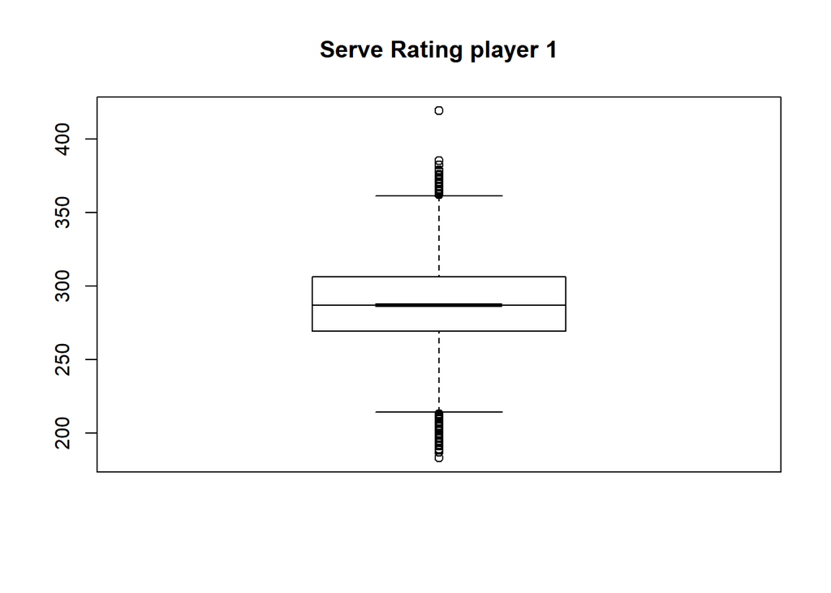

```r
boxplot(ATPstatistics$`Serve Rating 1`,notch=TRUE, main= ("Serve Rating player 1"))
```

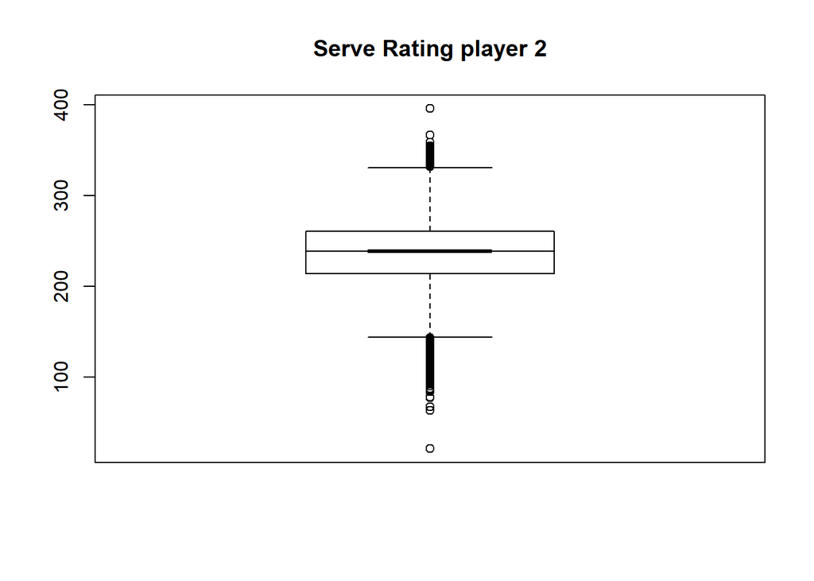

```r
boxplot(ATPstatistics$`Serve Rating 2`,notch=TRUE, main= ("Serve Rating player 2"))
```

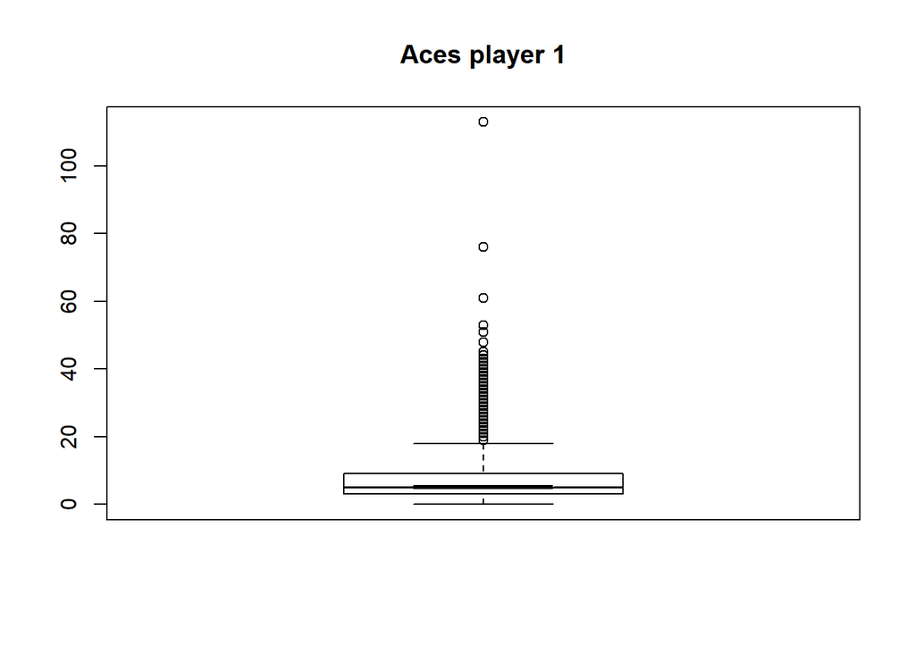

```r
boxplot(ATPstatistics$`Aces 1`,notch=TRUE, main= ("Aces player 1"))
```

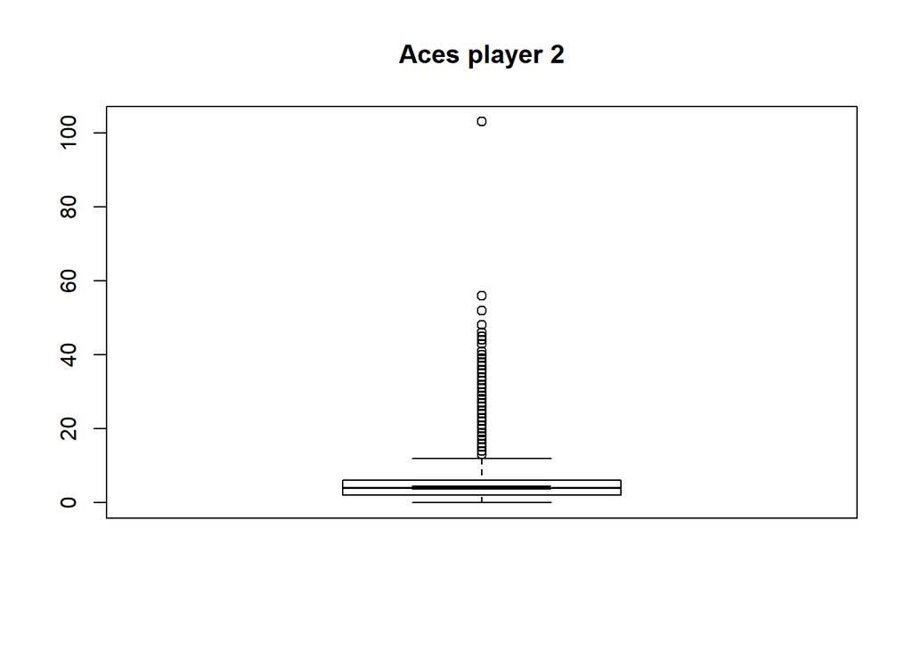

```r
boxplot(ATPstatistics$`Aces 2`,notch=TRUE, main= ("Aces player 2"))
```

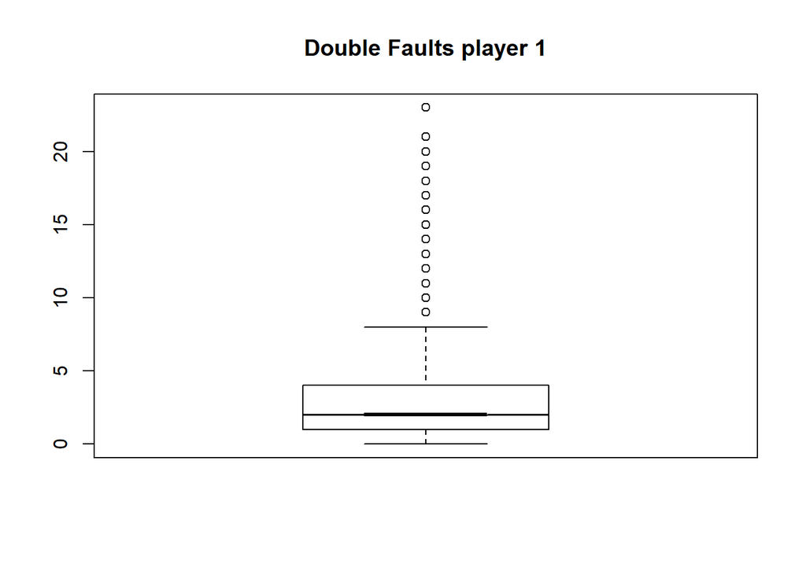

```r
boxplot(ATPstatistics$`Double Faults 1`,notch=TRUE, main= ("Double Faults player 1"))
```

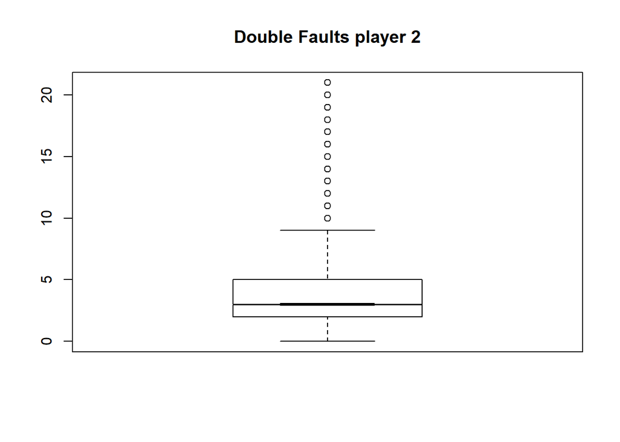

```r
boxplot(ATPstatistics$`Double Faults 2`,notch=TRUE, main= ("Double Faults player 2"))
```

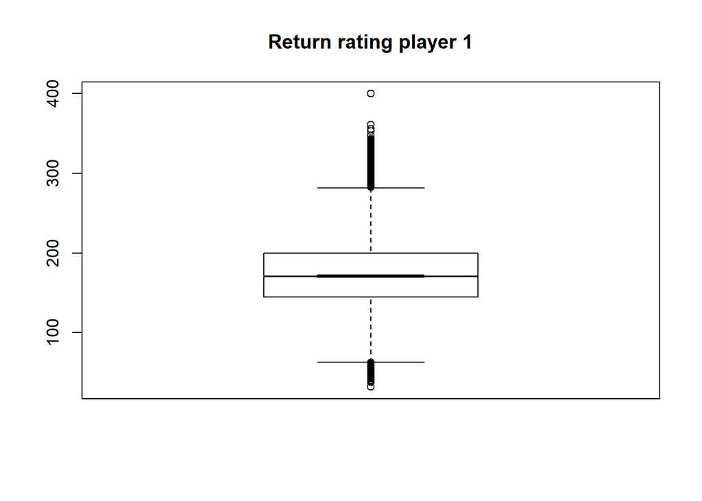

```r
boxplot(ATPstatistics$`Return Rating 1`,notch=TRUE, main= ("Return rating player 1"))
```

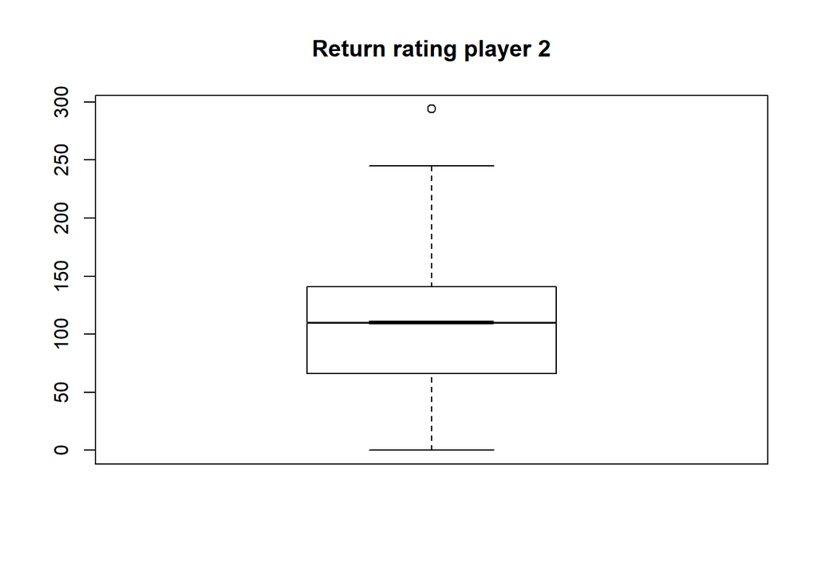

```r
boxplot(ATPstatistics$`Return Rating 2`,notch=TRUE, main= ("Return rating player 2"))
```

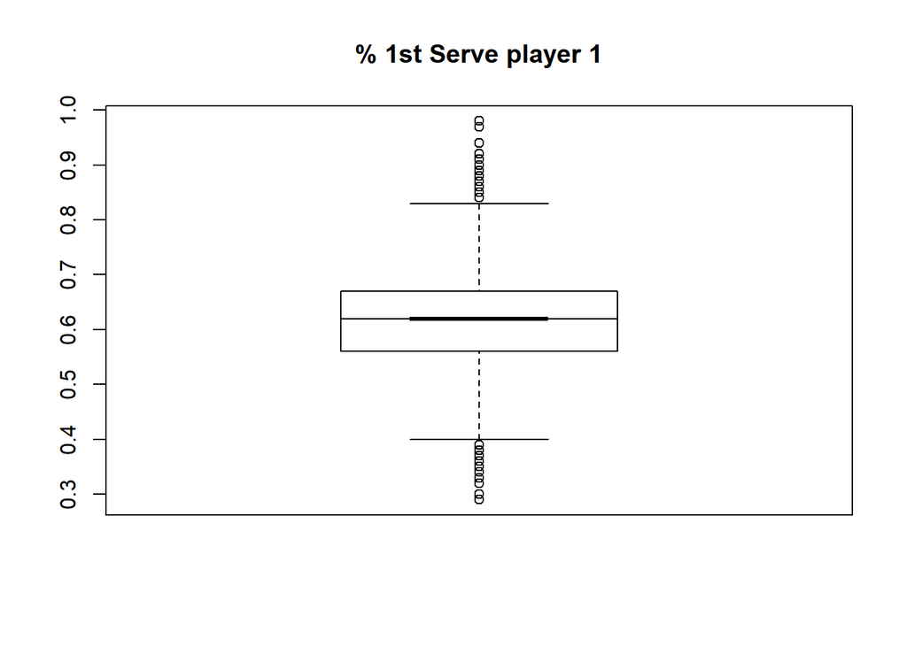

```r
boxplot(ATPstatistics$`% 1st Serve 1`,notch=TRUE, main= ("% 1st Serve player 1"))
```

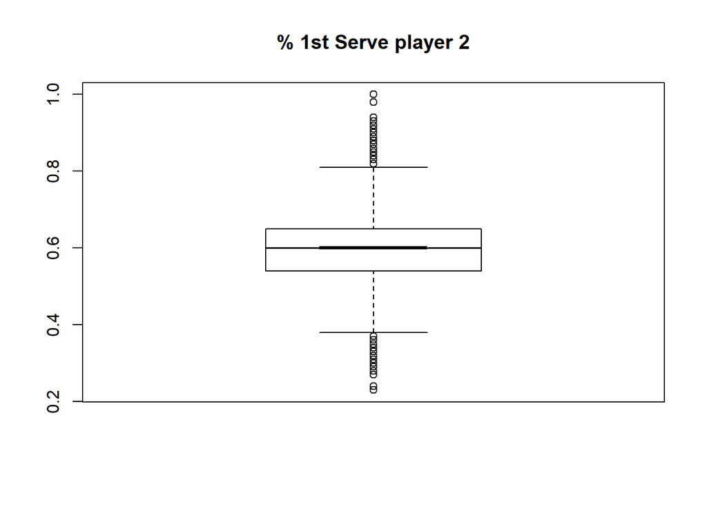

```r
boxplot(ATPstatistics$`% 1st Serve 2`,notch=TRUE, main= ("% 1st Serve player 2"))
```

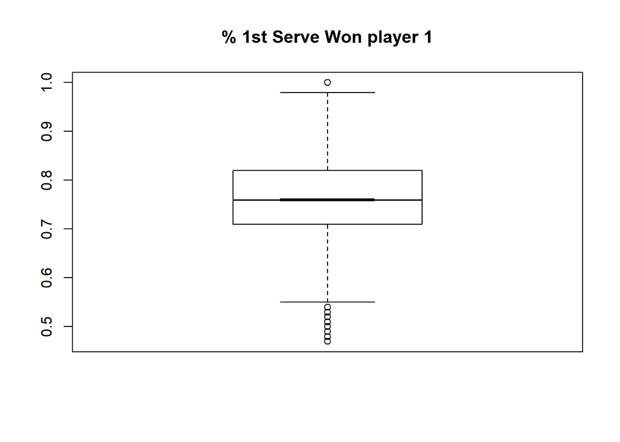

```r
boxplot(ATPstatistics$`% 1st Serve Won 1`,notch=TRUE, main= ("% 1st Serve Won player 1"))
```

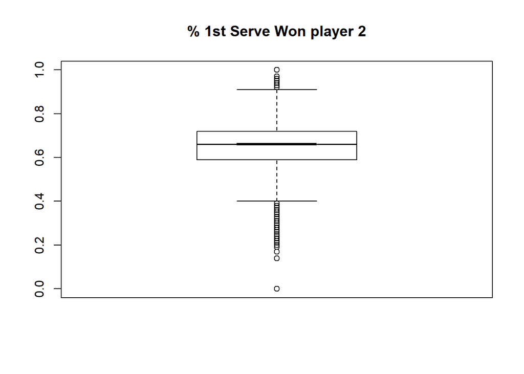

```r
boxplot(ATPstatistics$`% 1st Serve Won 2`,notch=TRUE, main= ("% 1st Serve Won player 2"))
```

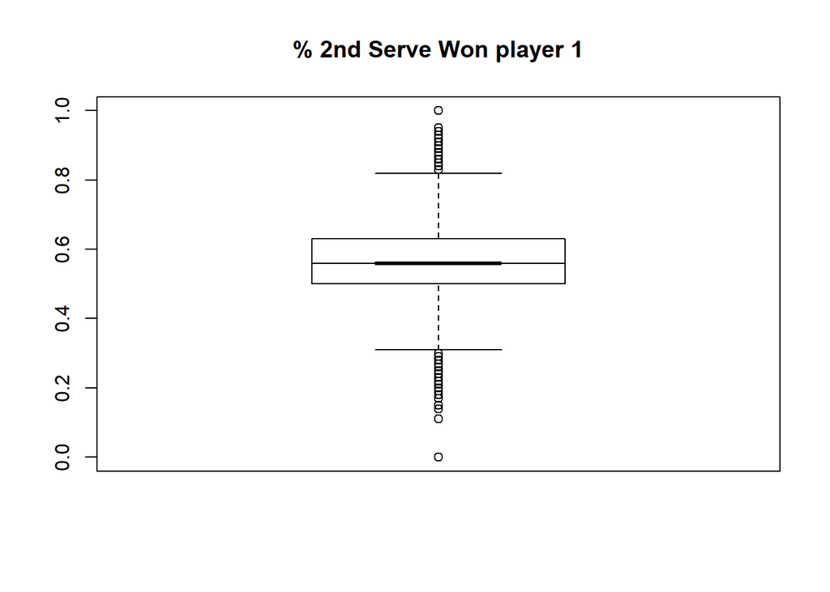

```r
boxplot(ATPstatistics$`% 2nd Serve Won 1`,notch=TRUE, main= ("% 2nd Serve Won player 1"))
```

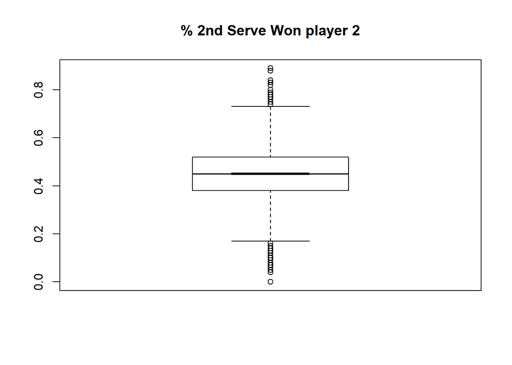

```r
boxplot(ATPstatistics$`% 2nd Serve Won 2`,notch=TRUE, main= ("% 2nd Serve Won player 2"))
```

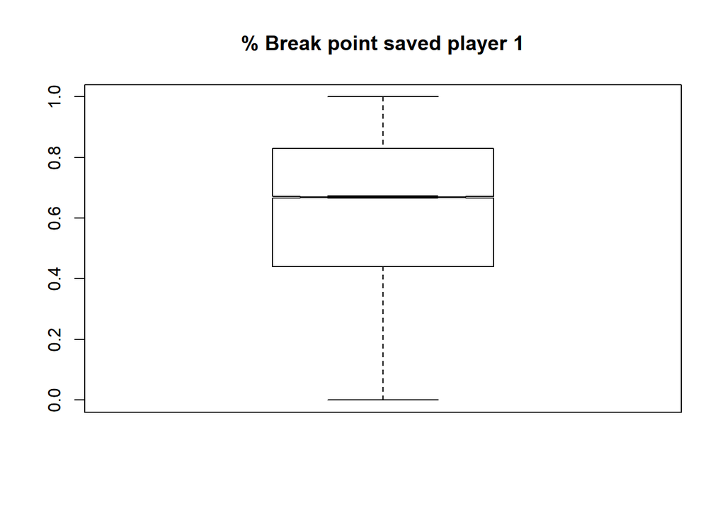

```r
boxplot(ATPstatistics$`% Break Point Saved 1`,notch=TRUE, main= ("% Break point saved player 1"))
```

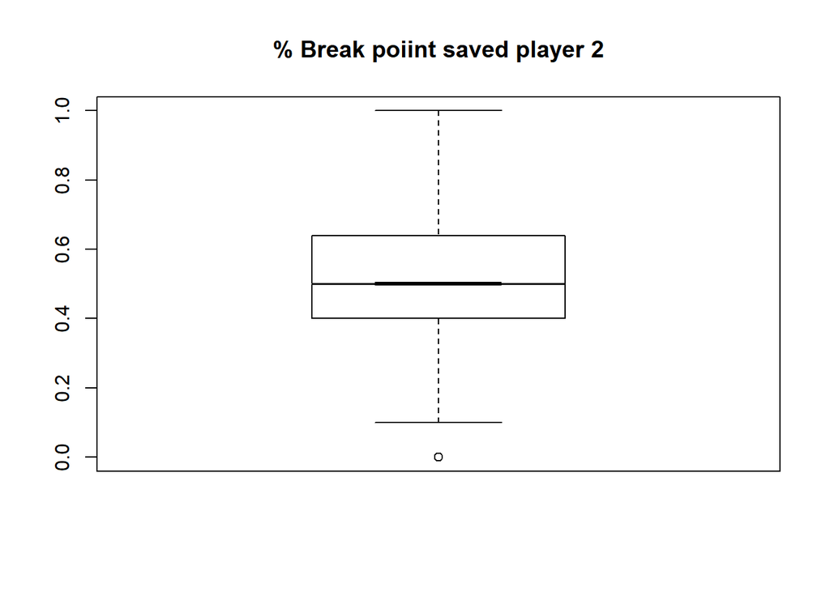

```r
boxplot(ATPstatistics$`% Break Point Saved 2`,notch=TRUE, main= ("% Break poiint saved player 2"))
```

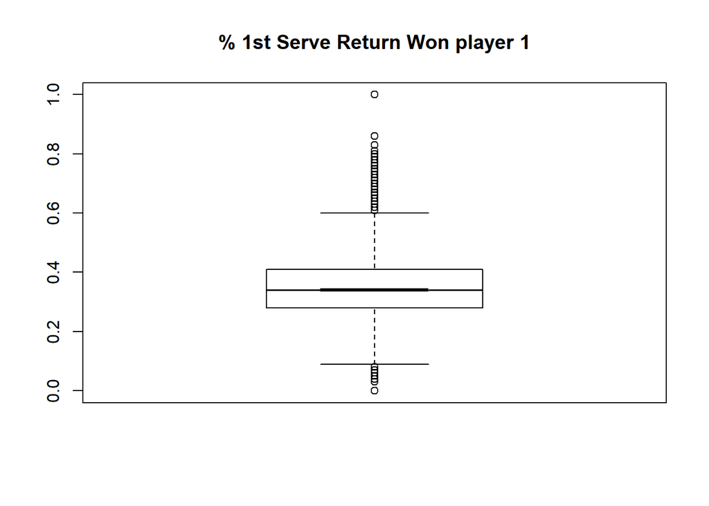

```r
boxplot(ATPstatistics$`% 1st Serve Return Won 1`,notch=TRUE, main= ("% 1st Serve Return Won player 1"))
```

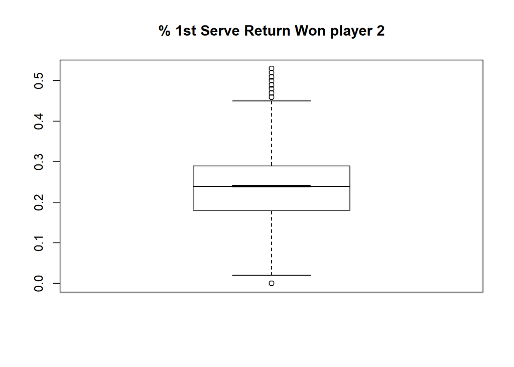

```r
boxplot(ATPstatistics$`% 1st Serve Return Won 2`,notch=TRUE, main= ("% 1st Serve Return Won player 2"))
```

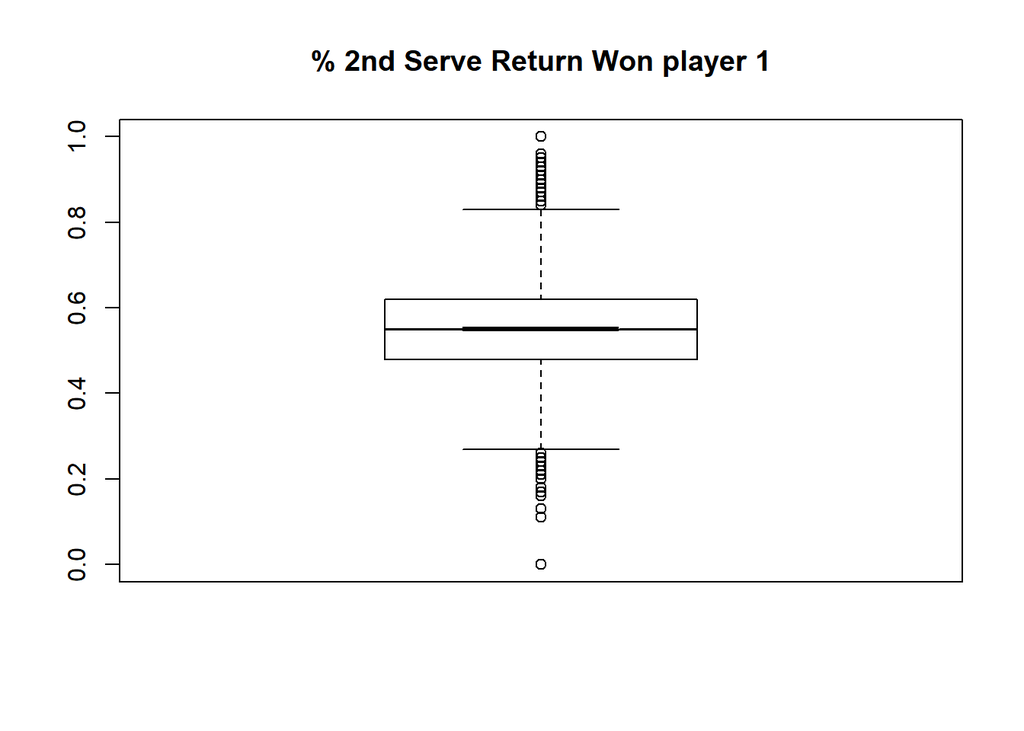

```r
boxplot(ATPstatistics$`% 2nd Serve Return Won 1`,notch=TRUE, main= ("% 2nd Serve Return Won player 1"))
```

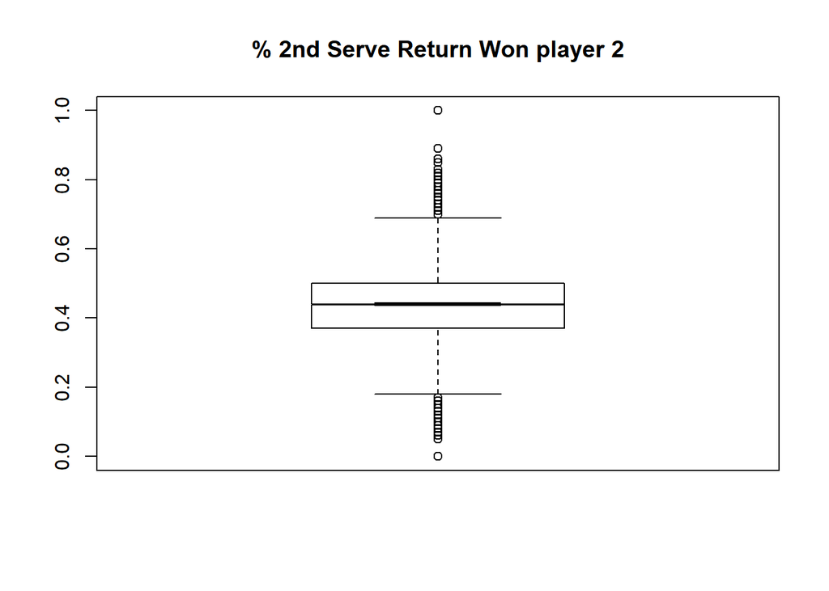

```r
boxplot(ATPstatistics$`% 2nd Serve Return Won 2`,notch=TRUE, main= ("% 2nd Serve Return Won player 2"))
```

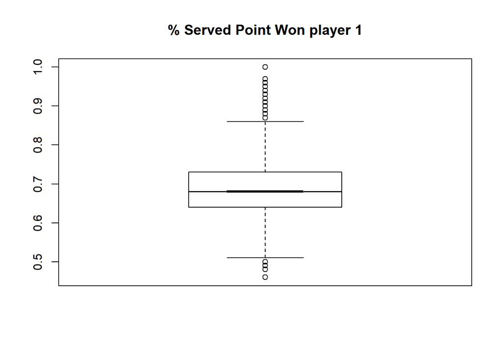

```r
boxplot(ATPstatistics$`% Served Point Won 1`,notch=TRUE, main= ("% Served Point Won player 1"))
```

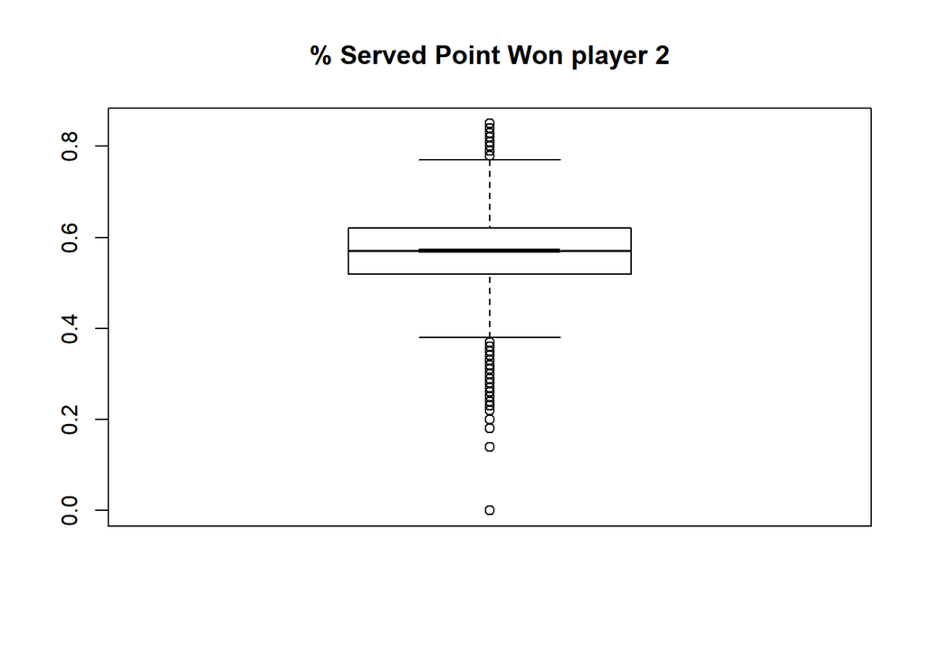

```r
boxplot(ATPstatistics$`% Served Point Won 2`,notch=TRUE, main= ("% Served Point Won player 2"))
```

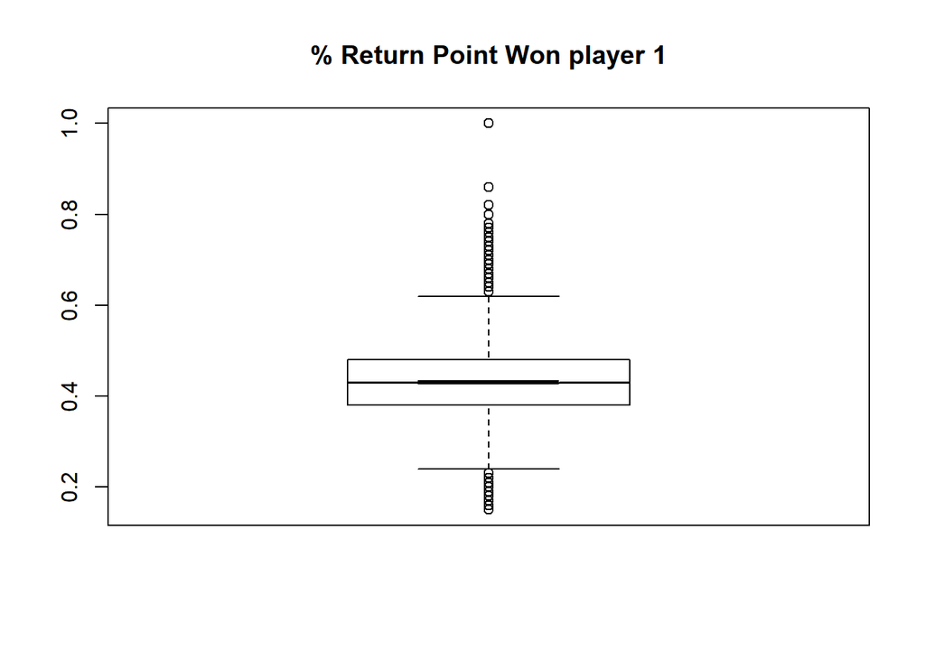

```r
boxplot(ATPstatistics$`% Return Point Won 1`,notch=TRUE, main= ("% Return Point Won player 1"))
```

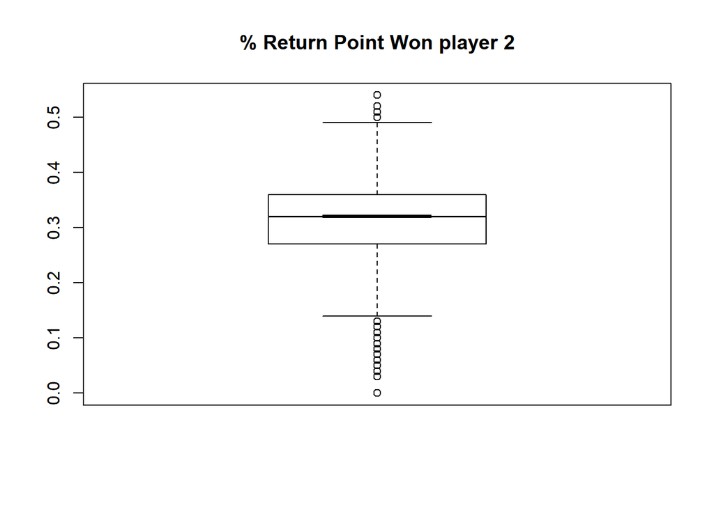

```r
boxplot(ATPstatistics$`% Return Point Won 2`,notch=TRUE, main= ("% Return Point Won player 2"))
```

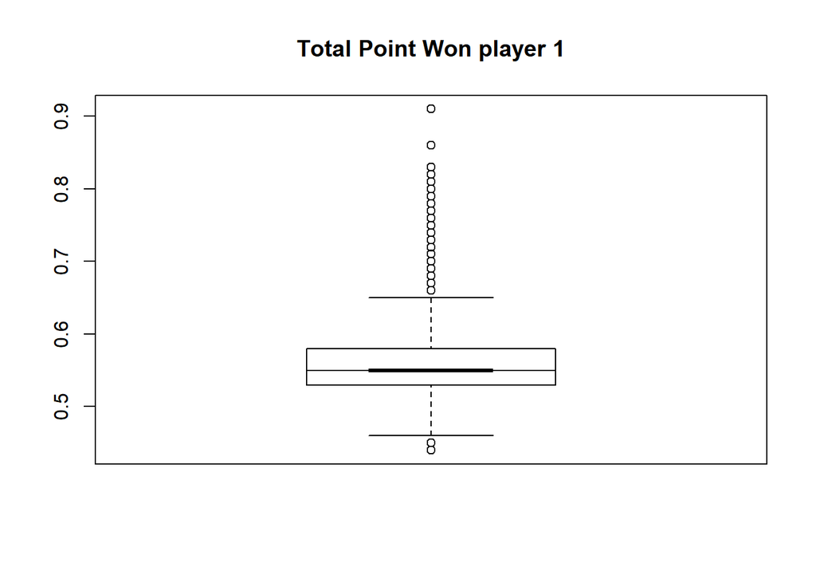

```r
boxplot(ATPstatistics$`% Total Point Won 1`,notch=TRUE, main= ("Total Point Won player 1"))
```

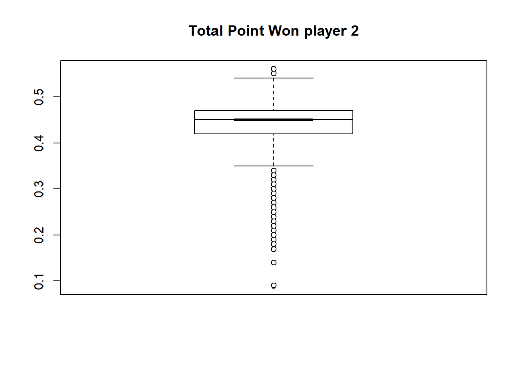

```r
boxplot(ATPstatistics$`% Total Point Won 2`,notch=TRUE, main= ("Total Point Won player 2"))
```

Como podemos observar en los diagramas de caja, existen bastantes valores extremos. No obstante nosotros hemos decidido mantener estos valores ya que, las estadísticas de los jugadores no tienen por que seguir una distribución normal, dentro del mismo torneo puede haber jugadores con un rendimiento muy alto por encima de la media, como por ejemplo Roger Federer y Rafael Nadal y otros que tengan un rendimiento muy bajo.

Por ejemplo, si analizamos los datos del atributo ‘Serve Rating 1’ que contiene la puntuación oficial de la ATP para el servicio del jugador 1, observamos los siguientes outliers.

```r
boxplot.stats(ATPstatistics$`Serve Rating 1`)$out
```

```
##   [1] 363 213 202 199 199 207 199 200 368 209 370 362 364 209 368 364 363
##  [18] 365 188 200 212 362 378 199 369 197 210 207 376 211 369 202 204 209
##  [35] 213 375 378 206 211 366 210 363 366 201 363 362 203 202 197 193 210
##  [52] 212 210 213 191 366 213 212 362 370 367 364 366 211 203 213 211 372
##  [69] 189 204 368 213 208 198 212 196 373 382 210 212 365 187 362 212 210
##  [86] 209 213 208 207 371 206 205 212 210 204 205 196 210 363 367 197 205
## [103] 201 209 198 385 212 207 213 209 183 195 211 208 363 364 207 198 204
## [120] 183 210 194 212 201 207 200 203 213 205 210 213 210 195 206 183 199
## [137] 206 365 369 362 206 197 210 419 369 379 196 212 365 367 207 210 204
## [154] 368 196 198 213
```

Para ver si estos datos son correctos, vamos a buscar el máximo de todos los outliers y averiguamos a qué partido corresponde para analizar los datos.

```r
max(boxplot.stats(ATPstatistics$`Serve Rating 1`)$out)
```

```
## [1] 419
```

```r
ATPstatistics[ATPstatistics$`Serve Rating 1` == max(boxplot.stats(ATPstatistics$`Serve Rating 1`)$out),c(2:3, 36:39)]
```

```
## # A tibble: 1 x 6
##   `Player 1` `Player 2`    Winner     Tournament `Started date` `Ended da~
##   <fctr>     <fctr>        <fctr>     <fctr>     <date>         <date>
## 1 John Isner Nicolas Mahut John Isner Wimbledon  2010-06-21     2010-07-04
```

Este partido pasó a la historia con varios records, entre ellos, el partido con más juegos de la historia, el de mayor duración, el de mayor puntuación y el partido con más ACEs. Adjuntamos un enlace con el detalle de este partido: https://es.wikipedia.org/wiki/Partido_Isner-Mahut_de_Wimbledon_2010

Al ser una fuente de datos oficial y referente en cuanto a las estadísticas de los torneos, es muy improbable que siendo revisados por un gran número de gente, exitan datos erroneos que no hayan sido reportados y corregidos.

## 4. Transformación de los datos

### 4.1 Normalización

En este apartado vamos a proceder a normalizar los datos. Esta transformación de los datos es algo fundamental como paso previo a utilizar los datos con algoritmos de aprendizaje automático. Los datos deben tener el mismo valor, por lo que lo suyo es que las variables numéricas deben de estar todas bajo el mismo rango, normalmente entre 0 y 1.

Tomamos cada atributo y lo dividimos entre su máximo, de esta forma obtenemos el rango deseado.

```r
ATPstatistics[,4]<-ATPstatistics[,4]/max(ATPstatistics[,4])
ATPstatistics[,5]<-ATPstatistics[,5]/max(ATPstatistics[,5])
ATPstatistics[,6]<-ATPstatistics[,6]/max(ATPstatistics[,6])
ATPstatistics[,7]<-ATPstatistics[,7]/max(ATPstatistics[,7])
ATPstatistics[,8]<-ATPstatistics[,8]/max(ATPstatistics[,8])
ATPstatistics[,9]<-ATPstatistics[,9]/max(ATPstatistics[,9])
ATPstatistics[,20]<-ATPstatistics[,20]/max(ATPstatistics[,20])
ATPstatistics[,21]<-ATPstatistics[,21]/max(ATPstatistics[,21])
summary(ATPstatistics[,c(4:8,20:21)])
```

```
##  Serve Rating 1   Serve Rating 2        Aces 1            Aces 2
##  Min.   :0.4368   Min.   :0.05303   Min.   :0.00000   Min.   :0.00000
##  1st Qu.:0.6420   1st Qu.:0.54040   1st Qu.:0.02655   1st Qu.:0.01942
##  Median :0.6850   Median :0.60354   Median :0.04425   Median :0.03884
##  Mean   :0.6850   Mean   :0.59646   Mean   :0.05698   Mean   :0.04572
##  3rd Qu.:0.7303   3rd Qu.:0.65909   3rd Qu.:0.07965   3rd Qu.:0.05825
##  Max.   :1.0000   Max.   :1.00000   Max.   :1.00000   Max.   :1.00000
##  Double Faults 1   Return Rating 1  Return Rating 2
##  Min.   :0.00000   Min.   :0.0800   Min.   :0.0000
##  1st Qu.:0.04348   1st Qu.:0.3625   1st Qu.:0.2245
##  Median :0.08696   Median :0.4275   Median :0.3741
##  Mean   :0.11170   Mean   :0.4341   Mean   :0.3694
##  3rd Qu.:0.17391   3rd Qu.:0.5000   3rd Qu.:0.4796
##  Max.   :1.00000   Max.   :1.0000   Max.   :1.0000
```

## 5. Análisis de los datos

### 5.1. Selección de datos a analizar / comparar

Antes de realizar el análisis de los datos, debemos seleccionar del dataset aquellos atribrutos que nos parezcan relevantes para construir nuestro modelo. Nosotros hemos decidido eliminar del dataset los atributos con el número total de juegos al servicio y al resto ya que, a priori, no nos aportan información relevante sobre el rendimiento de cada jugador.

```r
ATPstatistics<-ATPstatistics[-c(18:19)]
ATPstatistics<-ATPstatistics[-c(26:27)]
```

### 5.2. Comprobación de la normalidad de los datos

Comprobamos la normalidad de los datos mediante la función qqnorm y shapiro.test.

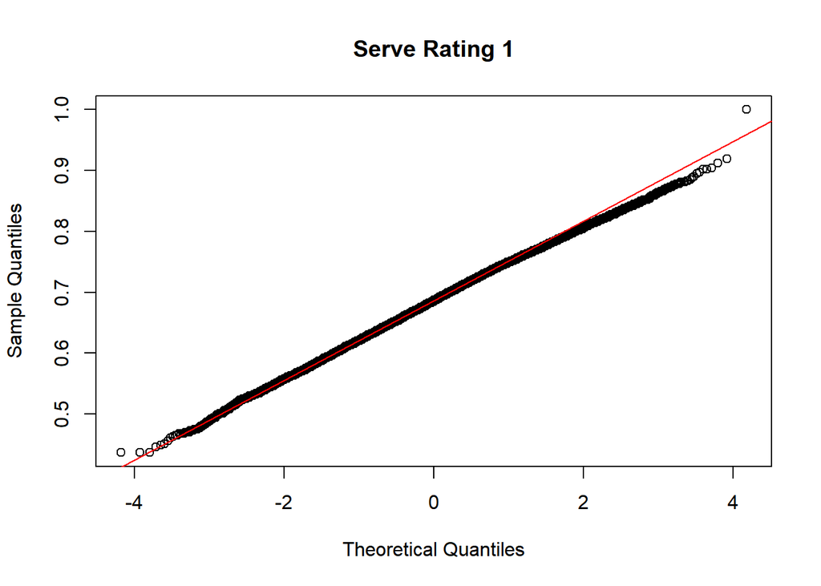

```
##
##  Shapiro-Wilk normality test
##
## data:  t(ATPstatistics[1:5000, i])
## W = 0.99938, p-value = 0.08934
```

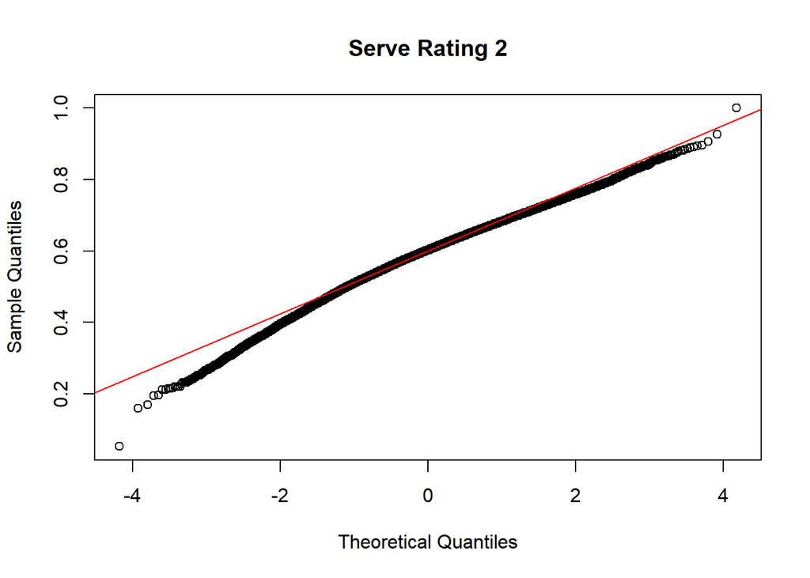

```
##
##  Shapiro-Wilk normality test
##
## data:  t(ATPstatistics[1:5000, i])
## W = 0.9947, p-value = 1.371e-12
```

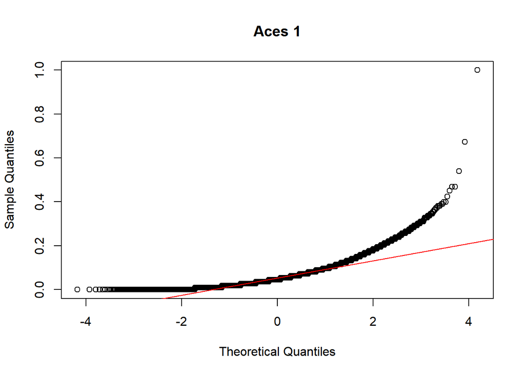

```
##
##  Shapiro-Wilk normality test
##
## data:  t(ATPstatistics[1:5000, i])
## W = 0.87731, p-value < 2.2e-16
```

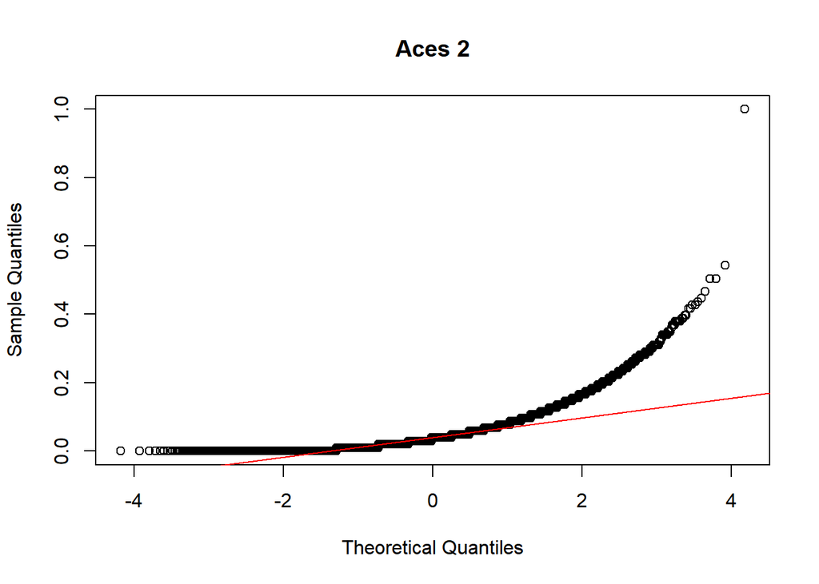

```
##
##  Shapiro-Wilk normality test
##
## data:  t(ATPstatistics[1:5000, i])
## W = 0.81101, p-value < 2.2e-16
```

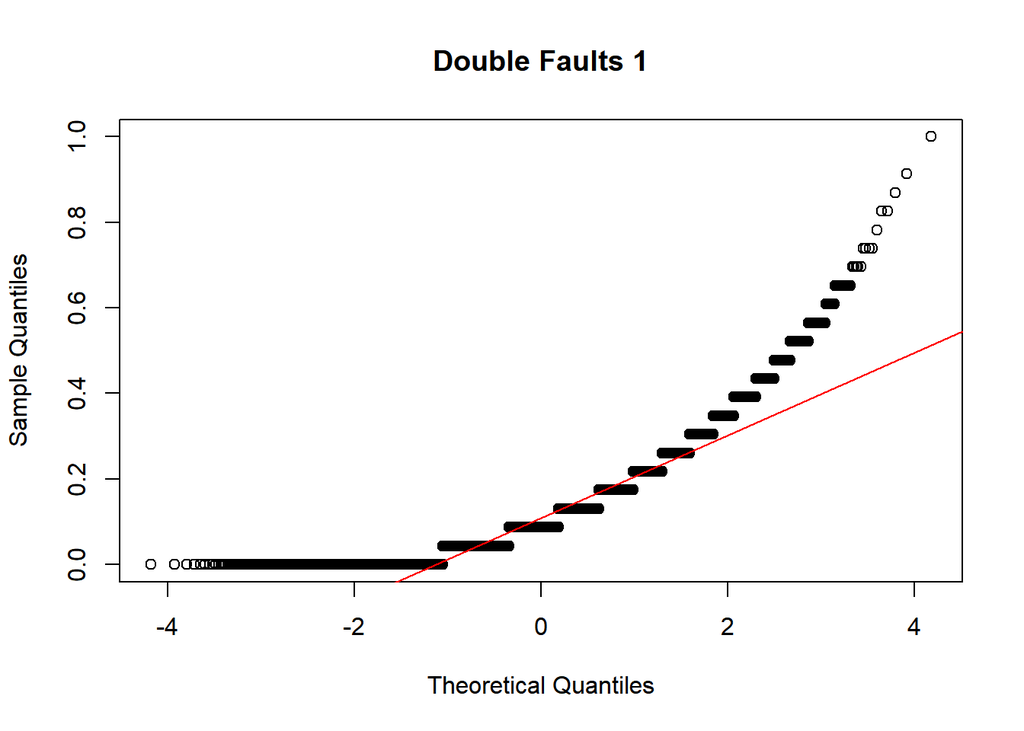

```
##
##  Shapiro-Wilk normality test
##
## data:  t(ATPstatistics[1:5000, i])
## W = 0.88334, p-value < 2.2e-16
```

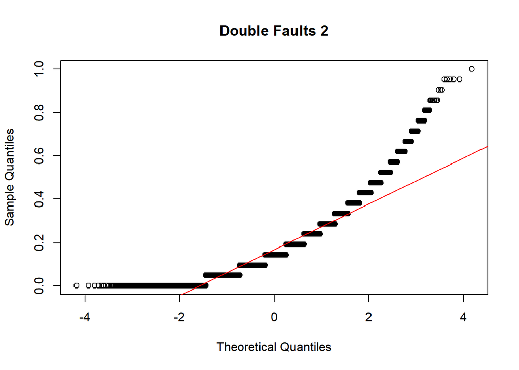

```
##
##  Shapiro-Wilk normality test
##
## data:  t(ATPstatistics[1:5000, i])
## W = 0.91495, p-value < 2.2e-16
```

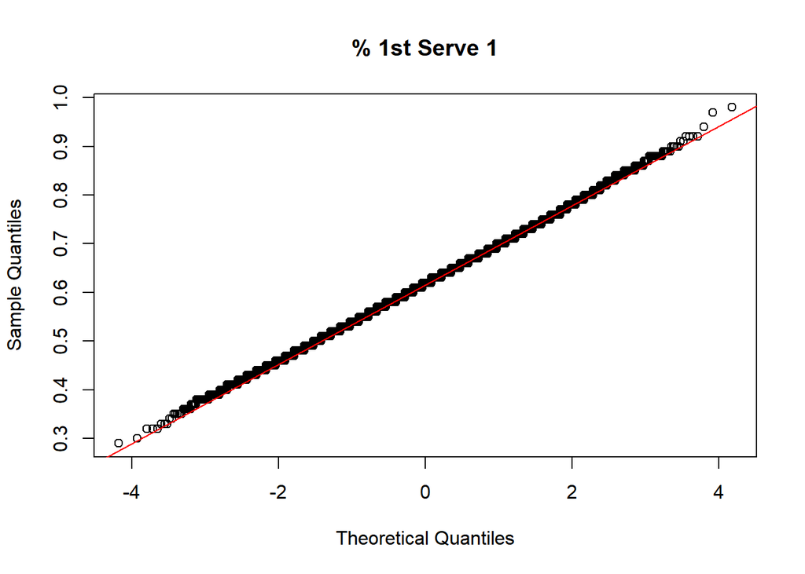

```
##
##  Shapiro-Wilk normality test
##
## data:  t(ATPstatistics[1:5000, i])
## W = 0.99809, p-value = 8.26e-06
```

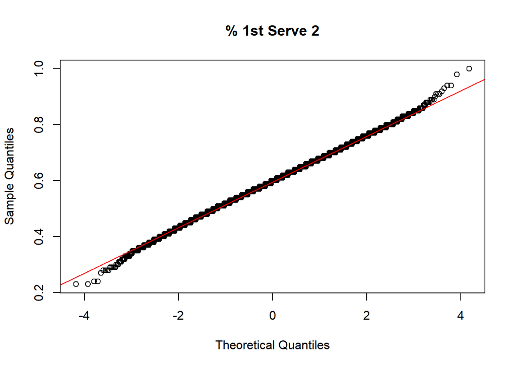

```
##
##  Shapiro-Wilk normality test
##
## data:  t(ATPstatistics[1:5000, i])
## W = 0.99844, p-value = 7.583e-05
```

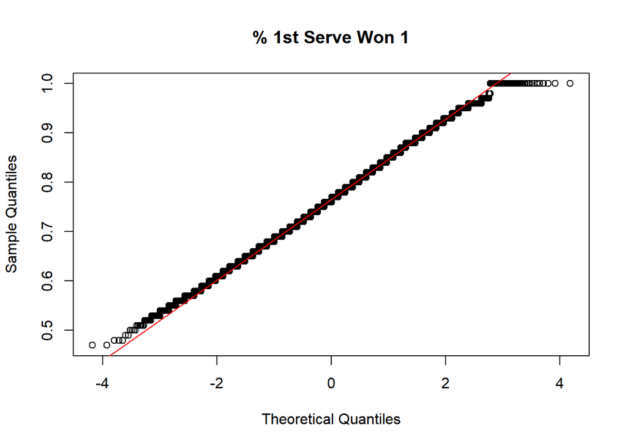

```
##
##  Shapiro-Wilk normality test
##
## data:  t(ATPstatistics[1:5000, i])
## W = 0.99782, p-value = 1.62e-06
```

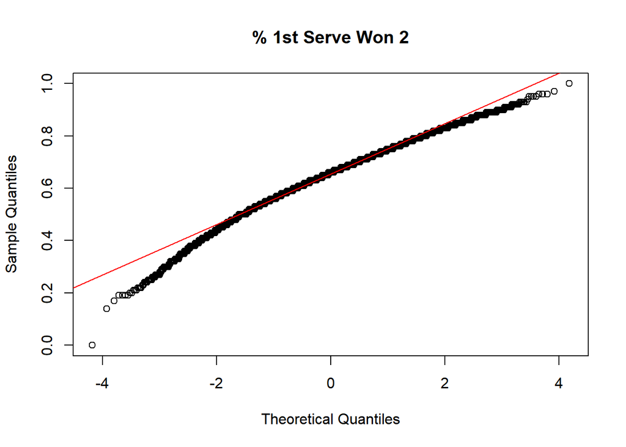

```
##
##  Shapiro-Wilk normality test
##
## data:  t(ATPstatistics[1:5000, i])
## W = 0.9923, p-value = 7.841e-16
```

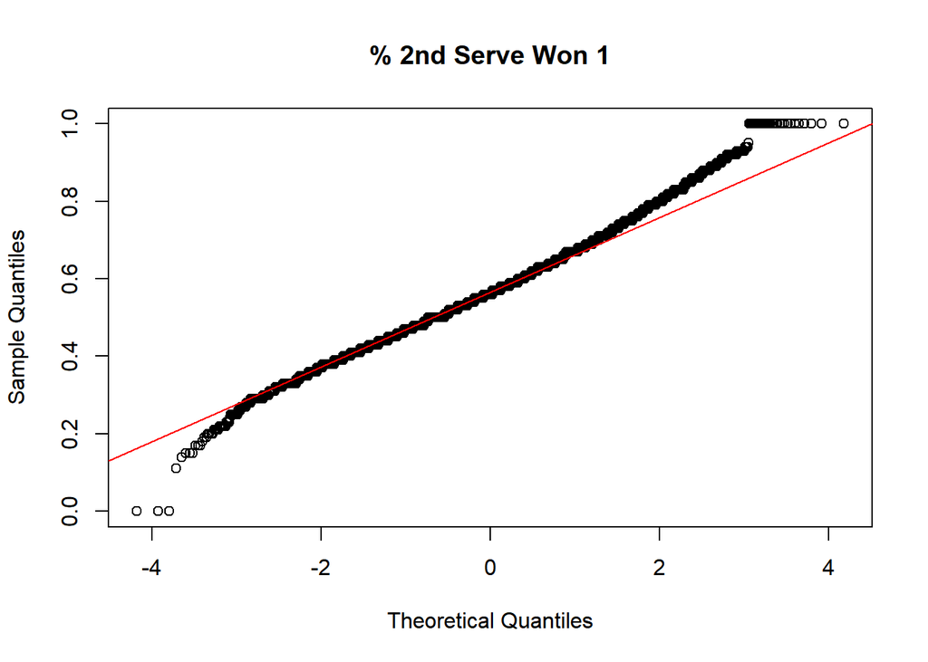

```
##
##  Shapiro-Wilk normality test
##
## data:  t(ATPstatistics[1:5000, i])
## W = 0.99327, p-value = 1.291e-14
```

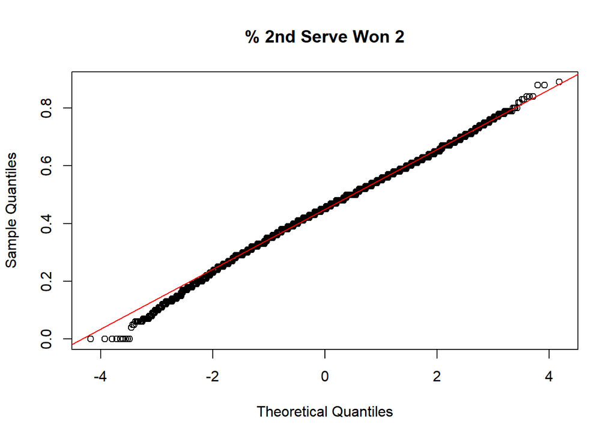

```
##
##  Shapiro-Wilk normality test
##
## data:  t(ATPstatistics[1:5000, i])
## W = 0.99745, p-value = 1.95e-07
```

[16 more figures not shown]

```
##
##  Shapiro-Wilk normality test
##
## data:  t(ATPstatistics[1:5000, i])
## W = 0.95148, p-value < 2.2e-16
```

```r
for (i in c(4:31)){
  qqnorm(t(ATPstatistics[,i]), main = colnames(ATPstatistics[,i]))
  qqline(t(ATPstatistics[,i]), col='red')
  print(shapiro.test(t(ATPstatistics[1:5000,i])))
}
```

Como podemos observar en las gráficas y en el resultado del test shapiro, salvo el atrituto ‘Serve Rating 1’, el resto tiene un Pvalue < 0.05 por lo que rechazamos le hipótesis nula y tomamos la aternativa; ninguno de estos atributos sigue una distribución normal.

### 5.3. Modelo de clasificación y predicción a partir de los datos

Vamos a proceder a crear un modelo de clasificación con el objetivo de predecir el ganador de nuevos partidos o torneos. Para ello, vamos a dividir el dataset en un grupo de entrenamiento y otro de test.

Utilizaremos el set de entrenamiento para entrenar un de machine learning basado en redes neuronales. Después, utilizaremos el dataset de test para validar este modelo.

Para entender esto mejor, vamos a tomar como ejemplo el último partido disputado entre Rafael Nadal y Roger Fededer. Las estadisticas de ese partido fueron las siguientes:

```r
ATPstatistics[(ATPstatistics$`Player 1` == "Rafael Nadal" | ATPstatistics$`Player 2` == "Rafael Nadal") & (ATPstatistics$`Player 1`=="Roger Federer" | ATPstatistics$`Player 2` == "Roger Federer"),][1,]
```

```
## # A tibble: 1 x 36
##   id_pa~ `Play~ `Play~ `Serv~ `Serv~ `Aces~ `Aces~ `Dou~ `Dou~ `% 1~ `% 1~
##    <int> <fctr> <fctr>  <dbl>  <dbl>  <dbl>  <dbl> <dbl> <dbl> <dbl> <dbl>
## 1   2018 Roger~ Rafae~  0.811  0.657 0.0885 0.0388     0     0 0.680 0.740
## # ... with 25 more variables: `% 1st Serve Won 1` <dbl>, `% 1st Serve Won
## #   2` <dbl>, `% 2nd Serve Won 1` <dbl>, `% 2nd Serve Won 2` <dbl>, `%
## #   Break Point Saved 1` <dbl>, `% Break Point Saved 2` <dbl>, `Return
## #   Rating 1` <dbl>, `Return Rating 2` <dbl>, `% 1st Serve Return Won 1`
## #   <dbl>, `% 1st Serve Return Won 2` <dbl>, `% 2nd Serve Return Won 1`
## #   <dbl>, `% 2nd Serve Return Won 2` <dbl>, `% Break Point Converted 1`
## #   <dbl>, `% Break Point Converted 2` <dbl>, `% Served Point Won 1`
## #   <dbl>, `% Served Point Won 2` <dbl>, `% Return Point Won 1` <dbl>, `%
## #   Return Point Won 2` <dbl>, `% Total Point Won 1` <dbl>, `% Total Point
## #   Won 2` <dbl>, Winner <fctr>, Tournament <fctr>, `Started date` <date>,
## #   `Ended date` <date>, Surface <fctr>
```

La estimación para este partido sería la siguiente:

```r
require(data.table)
variablesj1 <- c(1,seq(4,31,by = 2))
variablesj2 <- c(1,seq(5,32,by = 2))
otras_variables <- seq(33,ncol(ATPstatistics),by = 1)
resultado <- matrix(nrow=0,ncol=63)
partidos = 5
jugador1<-"Roger Federer"
jugador2<-"Rafael Nadal"
id_partido <- ATPstatistics[(ATPstatistics$`Player 1` == "Rafael Nadal" | ATPstatistics$`Player 2` == "Rafael Nadal") & (ATPstatistics$`Player 1`=="Roger Federer" | ATPstatistics$`Player 2` == "Roger Federer"),][1,1]
estadisticas_jugador1_1 <-ATPstatistics[which(ATPstatistics$`Player 1`==jugador1),variablesj1]
estadisticas_jugador1_2 <-ATPstatistics[which(ATPstatistics$`Player 2`==jugador1),variablesj2]
estadisticas_jugador2_1 <-ATPstatistics[which(ATPstatistics$`Player 1`==jugador2),variablesj1]
estadisticas_jugador2_2 <-ATPstatistics[which(ATPstatistics$`Player 2`==jugador2),variablesj2]
estadisticas_jugador1 <- rbind(as.matrix(estadisticas_jugador1_1),as.matrix(estadisticas_jugador1_2))
estadisticas_jugador2 <- rbind(as.matrix(estadisticas_jugador2_2),as.matrix(estadisticas_jugador2_1))
estadisticas_jugador1<-data.table(estadisticas_jugador1,key="id_partido")
estadisticas_jugador2<-data.table(estadisticas_jugador2,key="id_partido")
estadisticas_jugador1 <- estadisticas_jugador1[(which(estadisticas_jugador1$id_partido > id_partido[1])),2:ncol(estadisticas_jugador1)]
estadisticas_jugador2 <- estadisticas_jugador2[(which(estadisticas_jugador2$id_partido > id_partido[1])),2:ncol(estadisticas_jugador2)]
estadisticas_jugador1 <- estadisticas_jugador1[1:partidos,]
estadisticas_jugador2 <- estadisticas_jugador2[1:partidos,]
estadisticas_jugador1 <- cbind(t(colMeans(estadisticas_jugador1)),t(apply(estadisticas_jugador1,2,sd)))
estadisticas_jugador2 <- cbind(t(colMeans(estadisticas_jugador2)),t(apply(estadisticas_jugador2,2,sd)))
resultado <- cbind(id_partido,jugador1,jugador2,estadisticas_jugador1,estadisticas_jugador2,ATPstatistics[ATPstatistics$id_partido==2018,"Winner"],ATPstatistics[(ATPstatistics$`Player 1` == "Rafael Nadal" | ATPstatistics$`Player 2` == "Rafael Nadal") & (ATPstatistics$`Player 1`=="Roger Federer" | ATPstatistics$`Player 2` == "Roger Federer"),][1,otras_variables])
resultado
```

```
##   id_partido      jugador1     jugador2 Serve Rating 1     Aces 1
## 1       2018 Roger Federer Rafael Nadal      0.7108929 0.06366526
##   Double Faults 1 % 1st Serve 1 % 1st Serve Won 1 % 2nd Serve Won 1
## 1        0.073706         0.606             0.802             0.604
##   % Break Point Saved 1 Return Rating 1 % 1st Serve Return Won 1
## 1                 0.486       0.4393639                     0.37
##   % 2nd Serve Return Won 1 % Break Point Converted 1 % Served Point Won 1
## 1                    0.526                      0.46                0.724
##   % Return Point Won 1 % Total Point Won 1 Serve Rating 1     Aces 1
## 1                0.432               0.566     0.05502693 0.03717323
##   Double Faults 1 % 1st Serve 1 % 1st Serve Won 1 % 2nd Serve Won 1
## 1      0.09380504    0.06024948          0.137913          0.108074
##   % Break Point Saved 1 Return Rating 1 % 1st Serve Return Won 1
## 1             0.3262361       0.1269672                0.1036822
##   % 2nd Serve Return Won 1 % Break Point Converted 1 % Served Point Won 1
## 1                0.1463899                 0.1489966            0.1087658
##   % Return Point Won 1 % Total Point Won 1 Serve Rating 2     Aces 2
## 1            0.1125611          0.07402702      0.6903365 0.01644471
##   Double Faults 2 % 1st Serve 2 % 1st Serve Won 2 % 2nd Serve Won 2
## 1      0.06252588         0.664              0.74             0.604
##   % Break Point Saved 2 Return Rating 2 % 1st Serve Return Won 2
## 1                  0.37       0.5177789                    0.386
##   % 2nd Serve Return Won 2 % Break Point Converted 2 % Served Point Won 2
## 1                    0.622                      0.53                0.698
##   % Return Point Won 2 % Total Point Won 2 Serve Rating 2     Aces 2
## 1                 0.47               0.568      0.1072996 0.01217168
##   Double Faults 2 % 1st Serve 2 % 1st Serve Won 2 % 2nd Serve Won 2
## 1      0.02624586     0.1052616         0.1077033         0.1611831
##   % Break Point Saved 2 Return Rating 2 % 1st Serve Return Won 2
## 1             0.3394113       0.1171921               0.07436397
##   % 2nd Serve Return Won 2 % Break Point Converted 2 % Served Point Won 2
## 1                0.1958826                 0.1677796            0.1257776
##   % Return Point Won 2 % Total Point Won 2        Winner
## 1           0.09354143          0.08318654 Roger Federer
##                             Tournament Started date Ended date Surface
## 1 ATP World Tour Masters 1000 Shanghai   2017-10-08 2017-10-15    Hard
```

Ahora vamos a proceder a realizar la estimación de todos los partidos. El resultado se almaceneará en el fichero “dataset.csv”.

```r
partidos = 5
variablesj1 <- c(1,seq(4,31,by = 2))
variablesj2 <- c(1,seq(5,32,by = 2))
otras_variables <- seq(33,ncol(ATPstatistics),by = 1)
jugador1<-as.character(ATPstatistics$`Player 1`)
jugador2<-as.character(ATPstatistics$`Player 2`)
for(i in 1:nrow(ATPstatistics)){
  resultado <- matrix(nrow=0,ncol=63)
  estadisticas_jugador1_1 <-ATPstatistics[which(ATPstatistics$`Player 1`==jugador1[i]),variablesj1]
  estadisticas_jugador1_2 <-ATPstatistics[which(ATPstatistics$`Player 2`==jugador1[i]),variablesj2]
  estadisticas_jugador2_1 <-ATPstatistics[which(ATPstatistics$`Player 1`==jugador2[i]),variablesj1]
  estadisticas_jugador2_2 <-ATPstatistics[which(ATPstatistics$`Player 2`==jugador2[i]),variablesj2]
  estadisticas_jugador1 <- rbind(as.matrix(estadisticas_jugador1_1),as.matrix(estadisticas_jugador1_2))
  estadisticas_jugador2 <- rbind(as.matrix(estadisticas_jugador2_2),as.matrix(estadisticas_jugador2_1))
  estadisticas_jugador1<-data.table(estadisticas_jugador1,key="id_partido")
  estadisticas_jugador2<-data.table(estadisticas_jugador2,key="id_partido")
  estadisticas_jugador1 <- estadisticas_jugador1[estadisticas_jugador1$id_partido >ATPstatistics$id_partido[i],2:ncol(estadisticas_jugador1)]
  estadisticas_jugador2 <- estadisticas_jugador2[estadisticas_jugador2$id_partido > ATPstatistics$id_partido[i],2:ncol(estadisticas_jugador2)]
  if(nrow(estadisticas_jugador1)>= partidos & nrow(estadisticas_jugador2)>= partidos){
    estadisticas_jugador1 <- estadisticas_jugador1[1:partidos,]
    estadisticas_jugador2 <- estadisticas_jugador2[1:partidos,]
    estadisticas_jugador1 <- cbind(t(colMeans(estadisticas_jugador1)),t(apply(estadisticas_jugador1,2,sd)))
    estadisticas_jugador2 <- cbind(t(colMeans(estadisticas_jugador2)),t(apply(estadisticas_jugador2,2,sd)))
    if(i%%2 == 1){
      if(ATPstatistics$Winner[i]==jugador1[i])
        ganador = -1
      else
        ganador = 1
      resultado <- cbind(ATPstatistics$id_partido[i],jugador1[i],jugador2[i],estadisticas_jugador1,estadisticas_jugador2,ganador,ATPstatistics[i,otras_variables])
    }
    else{
      if(ATPstatistics$Winner[i]==jugador1[i])
        ganador = 1
      else
        ganador = -1
      resultado <- cbind(ATPstatistics$id_partido[i],jugador2[i],jugador1[i],estadisticas_jugador2,estadisticas_jugador1,ganador,ATPstatistics[i,otras_variables])
    }
    if(i == 1){
      dataset <- data.frame(resultado)
      colnames(dataset)<-colnames(resultado)
    }
    else
      dataset <- rbind((dataset),(resultado))
  }
}
#Fomateo de dataset
#dataframe <- as.data.frame()
#dataset <- as.data.frame(dataset)
colnames(dataset)[1:3]<-c("id_partido","Jugador 1","Jugador 2")
colnames(dataset)[4:17]<-paste("Media",colnames(dataset)[4:17])
colnames(dataset)[18:31]<-paste("Varianza",colnames(dataset)[18:31])
colnames(dataset)[32:45]<-paste("Media",colnames(dataset)[32:45])
colnames(dataset)[46:59]<-paste("Varianza",colnames(dataset)[46:59])
colnames(dataset)<-gsub(" ","_",colnames(dataset))
colnames(dataset)<-gsub("%","Pct", colnames(dataset))
dataset[,1]<-as.integer(dataset[,1])
for(i in 4:59)
  dataset[,i] <- as.double(dataset[,i])
dataset[,60]<-as.integer(dataset[,60])
#write.csv(dataset, "./Data/dataset.csv")
```

Una vez generado el dataset con las estimaciones, procedemos a generar el modelo. Para simplificar la práctica reduciremos los datos a 7500 registros en lugar de tomar el dataset entero.

```r
#dataset <- read.csv("./Data/dataset.csv")
#dataset <- dataset[,-1]
dataset_aux <- sample(1:nrow(dataset),7500)
index <- sample(1:7500,round(0.8*7500))
entrenamiento <- dataset[index,4:60]
test <- dataset[dataset_aux[-index],4:60]
nms<-colnames(dataset)[4:60]

#frml <- as.formula(paste("ganador ~", paste(nms[!nms %in% "ganador"], collapse = " + ")))

# Modelo con nnet
library("nnet")
NN = nnet(entrenamiento[,1:56],entrenamiento[,57],size = length(nms)/2, rang = 0.01, maxit=1000, decay = 0.0001, MaxNWts = 100000, linout=T, trace = F)
```

## 6. Representación gráfica de los datos

Revisamos la calidad del modelo que hemos generado mediante una matriz de confusión en la que se comparan los valores predichos por el modelo y los valores reales.

```r
library(caret)
# Exatitud con el set de entrenamiento
salida_entrenamiento <- NN$fitted.values
for(i in 1:length(salida_entrenamiento)){
  if(salida_entrenamiento[i] < 0)
    salida_entrenamiento[i] = -1
  else
    salida_entrenamiento[i] = 1
}
salida_entrenamiento<-as.factor(salida_entrenamiento)
entrenamiento[,57]<-as.factor(entrenamiento[,57])
confusionMatrix(data = salida_entrenamiento, entrenamiento[,57])
```

```
## Confusion Matrix and Statistics
##
##           Reference
## Prediction   -1    1
##         -1 2402  418
##         1   595 2585
##
##                Accuracy : 0.8312
##                  95% CI : (0.8214, 0.8406)
##     No Information Rate : 0.5005
##     P-Value [Acc > NIR] : < 2.2e-16
##
##                   Kappa : 0.6623
##  Mcnemar's Test P-Value : 3.206e-08
##
##             Sensitivity : 0.8015
##             Specificity : 0.8608
##          Pos Pred Value : 0.8518
##          Neg Pred Value : 0.8129
##              Prevalence : 0.4995
##          Detection Rate : 0.4003
##    Detection Prevalence : 0.4700
##       Balanced Accuracy : 0.8311
##
##        'Positive' Class : -1
##
```

```r
# Exatitud con el set de test
salida_test <- predict(NN, test[,1:56])
for(i in 1:length(salida_test)){
  if(salida_test[i] < 0)
    salida_test[i] = -1
  else
    salida_test[i] = 1
}
salida_test<-as.factor(salida_test)
test[,57]<-as.factor(test[,57])
confusionMatrix(data = salida_test, test[,57])
```

```
## Confusion Matrix and Statistics
##
##           Reference
## Prediction  -1   1
##         -1 413 298
##         1  335 454
##
##                Accuracy : 0.578
##                  95% CI : (0.5525, 0.6032)
##     No Information Rate : 0.5013
##     P-Value [Acc > NIR] : 1.563e-09
##
##                   Kappa : 0.1559
##  Mcnemar's Test P-Value : 0.1525
##
##             Sensitivity : 0.5521
##             Specificity : 0.6037
##          Pos Pred Value : 0.5809
##          Neg Pred Value : 0.5754
##              Prevalence : 0.4987
##          Detection Rate : 0.2753
##    Detection Prevalence : 0.4740
##       Balanced Accuracy : 0.5779
##
##        'Positive' Class : -1
##
```

## 7. Resolución del problema

Nuestro objetivo era construir un modelo de clasificación que permitiera predecir el ganador de nuevos partidos o torneos.

Si revisamos los datos que hemos obtenido sobre la validación del modelo que hemos creado, podemos observar que la exactitud con el set de test no es alta (~60%). Sin embargo, para ser un primer modelo no está nada mal. El modelo generado y su validación nos permite replantearnos los datos que usamos de ingesta, cómo los calculamos, los parámetros que habría que modificar para optimizar el modelo, usar otros algoritmos de clasificación (árboles de decisión, kNN), etc.

Por ejemplo, en este primer modelo sólo hemos tenido en cuenta las estadísticas de los 5 partidos anteriores de cada jugador. Podríamos considerar aumentar el número de partidos, incluir información adicional cruzando los datos con datos de meteorología, datos físicos de los tenistas, tipo de superficie, etc. Y con estos cambios volver a generar un modelo y revisar su bondad.